# Introduction to R

### A quick detour. Understanding the data.

Use `View()` command to view the `df` again

```r
View(df)
```

Data you will be analysing comes from a bulk RNA-seq experiment (more on that tomorrow!). In short, numbers represent nucleotide sequences (reads) generated during a Next Generation Sequencing (NGS) run. However, the number in each invidual cell is the total read count, or the total number of reads, aligned against a specific gene of the genome for each individual sample. A simplified diagram what this means can be found below.  
**(A)** Random reads generated during a NGS run

**(B)** These genes are then aligned to specific location in the rat genome, which in RNA-seq experiment, corresponds to the coding sequence (or exons) of the gene.

**(C)** As most genes are composed of multiple exonic and intronic regions the number of reads aligned againts each region can be neatly visualised in a *read coverage track*. Here each peak represents the number of reads aligned against that region of the reference genome.

**(D)** If we count all the reads aligned within the boundaries of a specific gene, e.g. Gene 1 or Gene 2, we get the **read count** for that gene in a specific sample. This information can then be summarised in a table.

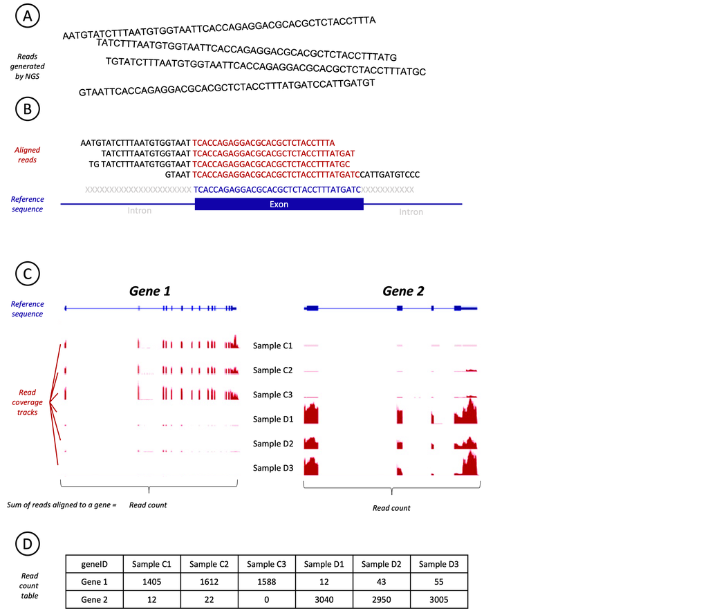

### 3.4. Annotating genes

If we ask R to print first few values of the `Ensembl_geneID` column of the `df` dataset we see that genes are currently encoded using unique [ENSEMBL stable identifiers](https://www.ensembl.org/info/genome/stable_ids/index.html).

```r
head(df$Ensembl_geneID, 10)
```

**Click here for results**

```
##  [1] "ENSRNOG00000046319" "ENSRNOG00000047964" "ENSRNOG00000050370"
##  [4] "ENSRNOG00000032365" "ENSRNOG00000040300" "ENSRNOG00000058808"
##  [7] "ENSRNOG00000061316" "ENSRNOG00000050129" "ENSRNOG00000040316"
## [10] "ENSRNOG00000023659"
```

The identifiers aim to be unambiguous and consistent across [ENSEMBL](https://www.ncbi.nlm.nih.gov/pmc/articles/PMC479121/) releases. **Unlike gene symbols** which can change as a result of improvements in scientific knowledge, stable identifiers should continue to refer to the same genomic features.

However, until we live without seemless [BCI](https://en.wikipedia.org/wiki/Brain%E2%80%93computer_interface) we need to use oftentimes inaccurate gene symbols for our brains to make sense what they are.

To convert Ensembl IDs to gene symbols we will use an R package called `org.Rn.eg.db` which we first need to install. Try using `install.packages()` command as learned before

**Click here if you can’t figure out the code**

```r
install.packages(org.Rn.eg.db)
```

We got an error saying that `'org.Rn.eg.db'` can’t be found. This is because `install.packages()` command installs packages contained in the **Comprehensive R Archive Network** ([CRAN](https://cran.r-project.org/)) which is R’s central software repository. `org.Rn.eg.db` package is simply not deposited to CRAN.

This is often the case for most bioinformatics tools. Luckily, there is [Bioconductor](https://www.bioconductor.org/) which is a free, open source and open development software project for the analysis and comprehension of genomic data. Bioconductor is based primarily on **R** and basically is an equivalent of CRAN for bioinformatics.

To find how to install `org.Rn.eg.db` from Bioconductor it is best to simply google `'R org.Rn.eg.db bioconductor'` and click on the 1st search result. Here you will find instructions on how to install the package under `Installation` and additional information about the package, e.g. its reference manual under `Documentation`.

**TASK. Install `org.Rn.eg.db` package from Bioconductor.**

**Click here if you can’t figure out the code**

First line of code checks if ‘BiocManager’ (Bioconductor installer) is installed on your device  
If it is not than the code instructs R to install it from CRAN using `install.packages()` Last, using `install()` command contained in `BiocManager` package R installs `org.Rn.eg.db` from Bioconductor depository

```r
if (!requireNamespace("BiocManager", quietly = TRUE))
    install.packages("BiocManager")
BiocManager::install("org.Rn.eg.db")
```

*Update all/some/none? [a/s/n]* <- answer a (all) in the console  
*Do you want to install from sources the packages which need compilation? (Yes/no/cancel)* <- answer no  
Installation might take a little while

Once a package is installed it has to be loaded into R using `library()` command.

**TASK. Load `org.Rn.eg.db` using `library()` command.**

**Click here if you can’t figure out the code**

```r
library(org.Rn.eg.db)
```

Finally, we can convert Ensembl IDs to gene symbols using `mapIds()` command contained in `org.Rn.eg.db` package.

```r
library(org.Rn.eg.db)
df$symbol <- mapIds(org.Rn.eg.db,
                    keys=df$Ensembl_geneID,
                    keytype="ENSEMBL",
                    column="SYMBOL",
                    multiVals="first")
```

- We will write converted gene symbols as a new column in `df` using `$` and `<-` operators
- 1st argument indicates that information about gene symbols is contained in `org.Rn.eg.db` package, i.e. source file
- 2nd argument `keys` indicates the source of ENSEMBL IDs we wish to convert, i.e. input data
- 3rd argument `keytype` instructs what type of identifier was used - we indicate `"ENSEMBL"` (there are many alternatives!)
- 4th argument `column` indicates what type of output we wish to retrieve - we indicate `"SYMBOL"` to obtain gene symbols; Additional data types contained in `org.Rn.eg.db` can be looked up using `columns(org.Rn.eg.db)`
- 5th argument `multiVals` instructs what to do if Ensembl ID is associated with multiple gene symbols - we indicate `"first"` for the 1st symbol that comes back to be returned.

We can inspect if it worked using `head()` command.

**Click here for results**

```r
head(df)
```

```
##       Ensembl_geneID Sample_C1 Sample_C2 Sample_C3 Sample_C4 Sample_C5
## 1 ENSRNOG00000046319         0         0         0         0         0
## 2 ENSRNOG00000047964         0         0         0         0         0
## 3 ENSRNOG00000050370         0         0         0         0         0
## 4 ENSRNOG00000032365         0         0         0         0         0
## 5 ENSRNOG00000040300         1         1         1         1         0
## 6 ENSRNOG00000058808         0         0         0         0         0
##   Sample_D1 Sample_D2 Sample_D3 Sample_D4 Sample_D5 symbol
## 1         0         0         0         0         0   <NA>
## 2         0         0         0         0         0   <NA>
## 3         0         0         0         0         0 Vom2r6
## 4         0         0         0         0         0 Vom2r5
## 5         3         7         0         6         2 Raet1e
## 6         0         0         0         0         0   <NA>
```

We can see that **ENSRNOG00000050370** corresponds to *Vom2r6* while **ENSRNOG00000040300** corresponds to *Raet1e* genes

We can also add gene description as another column. Use `columns(org.Rn.eg.db)` command to see what other gene annotations are available. `GENENAME` represents gene description.

```r
columns(org.Rn.eg.db)
```

**TASK. Use `mapIds()` as before to retrieve gene descriptions into a new column called `description` in `df` data frame.**

**Click here if you can’t figure out the code**

```r
library(org.Rn.eg.db)
df$description <- mapIds(org.Rn.eg.db,
                    keys=df$Ensembl_geneID,
                    keytype="ENSEMBL",
                    column="GENENAME",
                    multiVals="first")
```

```r
head(df)
```

```
##       Ensembl_geneID Sample_C1 Sample_C2 Sample_C3 Sample_C4 Sample_C5
## 1 ENSRNOG00000046319         0         0         0         0         0
## 2 ENSRNOG00000047964         0         0         0         0         0
## 3 ENSRNOG00000050370         0         0         0         0         0
## 4 ENSRNOG00000032365         0         0         0         0         0
## 5 ENSRNOG00000040300         1         1         1         1         0
## 6 ENSRNOG00000058808         0         0         0         0         0
##   Sample_D1 Sample_D2 Sample_D3 Sample_D4 Sample_D5 symbol
## 1         0         0         0         0         0   <NA>
## 2         0         0         0         0         0   <NA>
## 3         0         0         0         0         0 Vom2r6
## 4         0         0         0         0         0 Vom2r5
## 5         3         7         0         6         2 Raet1e
## 6         0         0         0         0         0   <NA>
##                         description
## 1                              <NA>
## 2                              <NA>
## 3         vomeronasal 2 receptor, 6
## 4         vomeronasal 2 receptor, 5
## 5 retinoic acid early transcript 1E
## 6                              <NA>
```

Brilliant! Now we have both gene symbols and gene descriptions associated with each Ensembl ID.

### 3.5. Subsetting columns and deriving new data

Brilliant! The data frame now has both gene symbols and descriptions. Let’s start exploring the data!

First, let’s derive the average read count for each gene across all samples. There is multiple ways we could do this in R. For this tutorial we will use `rowMeans()` command which is native to R.

**TASK. Use `rowMeans()` for `df` to derive average read count for each gene.**

**Click here if you can’t figure out the code**

```r
rowMeans(df)
```

**Click here for results**

R prints out an error: `Error in rowMeans(df) : 'x' must be numeric`.  
This is because `rowMeans()` only permits the use of **numeric elements** while the `df` data frame contains ‘Ensembl_geneID’, ‘symbol’ and ‘description’ columns containing **character elements**.

**TASK. Derive average read count using `rowMeans()` for each column containing read counts**

Hint. Lookup which columns correspond to experimental samples using `colnames()` and then indicate the desired columns using the `[ ]` and `:` operators for the `df` used as input for `rowMeans()`.

**Click here if you can’t figure out the code**

```r
colnames(df)
```

```
##  [1] "Ensembl_geneID" "Sample_C1"      "Sample_C2"      "Sample_C3"
##  [5] "Sample_C4"      "Sample_C5"      "Sample_D1"      "Sample_D2"
##  [9] "Sample_D3"      "Sample_D4"      "Sample_D5"      "symbol"
## [13] "description"
```

You can see that columns corresponding to samples C1-5 and D1-5 are the 2-11 columns of the data frame

```r
rowMeans(df[2:11])
```

```
##   [1]    0.0    0.0    0.0    0.0    2.2    0.0   16.2    1.3    0.0    1.3
##  [11]   11.4    1.2    0.0    0.0 5925.6    0.0 2357.4  252.0 1566.4  195.2
##  [21]  731.6    0.4    0.0  961.0   16.8 2788.3  183.4    0.0    0.0 4215.8
##  [31]    0.1  290.1    0.5 4587.6    1.2    0.0   31.9  126.3    0.0 2311.4
##  [41]    0.1    7.4 1200.0  612.9    0.0  127.6    0.0    0.0    0.1    0.4
##  [51] 3472.4   21.5  855.4    0.0  798.7    0.3    0.7  613.9  475.6 1429.3
##  [61] 1015.8   73.9    1.2 1248.7 2511.6    0.1 1155.2 1564.7    0.0   20.5
##  [71]    0.0    0.0    0.0    0.0    0.0    0.0    0.0    0.0   12.7    0.0
##  [81]    0.0    0.0    0.0    0.5    0.0    0.3    0.0    0.4   18.7    0.0
##  [91]    0.2    0.0    0.1 1341.6    0.0   21.7    0.7 1014.8  259.2 1020.5
```

You did it! Although having thousands of average counts printed in the console is not very useful.

**TASK. Create a new column in `df` named ‘means’ containing the average read count for each gene across all samples.**

Hint. To do this use the `$` and `<-` operators as before.

**Click here if you can’t figure out the code**

```r
df$means <- rowMeans(df[2:11])
```

We can inspect whether it worked using `head()`

```r
head(df) # check whether it worked
```

```
##       Ensembl_geneID Sample_C1 Sample_C2 Sample_C3 Sample_C4 Sample_C5
## 1 ENSRNOG00000046319         0         0         0         0         0
## 2 ENSRNOG00000047964         0         0         0         0         0
## 3 ENSRNOG00000050370         0         0         0         0         0
## 4 ENSRNOG00000032365         0         0         0         0         0
## 5 ENSRNOG00000040300         1         1         1         1         0
## 6 ENSRNOG00000058808         0         0         0         0         0
##   Sample_D1 Sample_D2 Sample_D3 Sample_D4 Sample_D5 symbol
## 1         0         0         0         0         0   <NA>
## 2         0         0         0         0         0   <NA>
## 3         0         0         0         0         0 Vom2r6
## 4         0         0         0         0         0 Vom2r5
## 5         3         7         0         6         2 Raet1e
## 6         0         0         0         0         0   <NA>
##                         description means
## 1                              <NA>   0.0
## 2                              <NA>   0.0
## 3         vomeronasal 2 receptor, 6   0.0
## 4         vomeronasal 2 receptor, 5   0.0
## 5 retinoic acid early transcript 1E   2.2
## 6                              <NA>   0.0
```

The last column now contains the average read counts. Yay!

**TASK. Next, derive the average read count just for the control and just for the dehydrated samples and save them as a new columns named ‘mean.con’ and ‘mean.deh’ in `df`**

**Click here if you can’t figure out the code**

You can do it! Just follow the steps used in the previous example.

**Click here if you are really stuck**

```r
df$mean.con <- rowMeans(df[,2:6]) # average values of controls
df$mean.deh <- rowMeans(df[,7:11]) # average values of dehydrated
```

Well done! Now use `colnames()` and `head()` commands to check if it worked.

**Click here for results**

```
##  [1] "Ensembl_geneID" "Sample_C1"      "Sample_C2"      "Sample_C3"
##  [5] "Sample_C4"      "Sample_C5"      "Sample_D1"      "Sample_D2"
##  [9] "Sample_D3"      "Sample_D4"      "Sample_D5"      "symbol"
## [13] "description"    "means"          "mean.con"       "mean.deh"
```

```
##       Ensembl_geneID Sample_C1 Sample_C2 Sample_C3 Sample_C4 Sample_C5
## 1 ENSRNOG00000046319         0         0         0         0         0
## 2 ENSRNOG00000047964         0         0         0         0         0
## 3 ENSRNOG00000050370         0         0         0         0         0
## 4 ENSRNOG00000032365         0         0         0         0         0
## 5 ENSRNOG00000040300         1         1         1         1         0
## 6 ENSRNOG00000058808         0         0         0         0         0
##   Sample_D1 Sample_D2 Sample_D3 Sample_D4 Sample_D5 symbol
## 1         0         0         0         0         0   <NA>
## 2         0         0         0         0         0   <NA>
## 3         0         0         0         0         0 Vom2r6
## 4         0         0         0         0         0 Vom2r5
## 5         3         7         0         6         2 Raet1e
## 6         0         0         0         0         0   <NA>
##                         description means mean.con mean.deh
## 1                              <NA>   0.0      0.0      0.0
## 2                              <NA>   0.0      0.0      0.0
## 3         vomeronasal 2 receptor, 6   0.0      0.0      0.0
## 4         vomeronasal 2 receptor, 5   0.0      0.0      0.0
## 5 retinoic acid early transcript 1E   2.2      0.8      3.6
## 6                              <NA>   0.0      0.0      0.0
```

### 3.6. Sorting and filtering data

As we have now computed the average read count across samples we can sort the data to see which genes are the most abundantly expressed in our dataset.

For this we will use a new package called [`dplyr`](https://dplyr.tidyverse.org/) which is part of a bigger [`tidyverse`](https://www.tidyverse.org/) collection of R packages. First, let’s load `dplyr` into R using `library()` command.

**Click here if you can’t figure out the code**

```r
library(dplyr)
```

We will use the `arrange()` function contained in `dplyr` package to sort genes in `df` in decreasing order based on average read count. Although not necessary, I highly recommend using the double colon operator `::` to indicate to which package the command you are using belongs to. This makes for a more readable and transparent code!

Here, the 1st argument is the input data frame. While the 2nd argument instructs `arrange()` how we wish to sort the data frame. In this example we instruct R to sort the `df` in descending order `desc()` based on values in ‘means’ column.

```r
dplyr::arrange(df, desc(means)) #Sorting by mean reads count in descending order
```

**Click here for results**

```
##       Ensembl_geneID Sample_C1 Sample_C2 Sample_C3 Sample_C4 Sample_C5
## 1 ENSRNOG00000034234    801574    823254    869097    635491    757701
## 2 ENSRNOG00000031979    579853    567980    574038    438134    532600
## 3 ENSRNOG00000031033    488238    462219    416499    322726    350350
## 4 ENSRNOG00000030700    381673    377171    374708    293368    341400
## 5 ENSRNOG00000030371    336850    351084    359882    309987    348925
## 6 ENSRNOG00000030644    393943    334223    343259    254123    306509
## 7 ENSRNOG00000031766    340643    347300    335315    250674    281350
## 8 ENSRNOG00000021229    203193    119432    180402    152163    195012
##   Sample_D1 Sample_D2 Sample_D3 Sample_D4 Sample_D5 symbol
## 1    843991    803420    798712    739662    726652   COX1
## 2    569009    495278    518082    528137    475542   ATP6
## 3    415692    354065    388316    398697    380313    ND2
## 4    374996    347109    357059    324918    330772   COX3
## 5    353151    310838    333069    310064    298213   COX2
## 6    350529    335420    335910    341291    293971    ND1
## 7    326677    297968    296184    300258    291500   CYTB
## 8    197010    231226    260863    193372    210251    Avp
##                      description    means mean.con mean.deh
## 1 cytochrome c oxidase subunit 1 779955.4 777423.4 782487.4
## 2               ATPase subunit 6 527865.3 538521.0 517209.6
## 3   NADH dehydrogenase subunit 2 397711.5 408006.4 387416.6
## 4 cytochrome c oxidase subunit 3 350317.4 353664.0 346970.8
## 5                          COXII 331206.3 341345.6 321067.0
## 6   NADH dehydrogenase subunit 1 328917.8 326411.4 331424.2
## 7                   cytochrome b 306786.9 311056.4 302517.4
## 8           arginine vasopressin 194292.4 170040.4 218544.4
```

You can learn more about `arrange()` by looking it up with `help()`

```r
help(arrange)
```

If you scroll up you can see that the top 5 most expressed gene in the hypothalamic supraoptic nucleus are:  
**(1)** *COX1* - cytochrome c oxidase subunit 1  
**(2)** *ATP6* - ATPase subunit 6  
**(3)** *ND2* - NADH dehydrogenase subunit 2  
**(4)** *COX3* - cytochrome c oxidase subunit 3  
**(5)** *COX2* - COXII  
Note here the 8th most abundantly expressed gene:  
**(8)** *Avp* - arginine vasopressin

Again, it is not very useful to have thousands of genes printed on the console.

**TASK. Save the sorted results as a new data frame called ‘df.sort’**

Hint. Use `<-` operator to do this.

**Click here if you can’t figure out the code**

```r
df.sort <- dplyr::arrange(df, desc(means)) #Sorting by mean reads count in descending order
```

Well done! Now it is easy to look up the top 5 most abundantly and least expressed genes using `head()` and `tail()` commands.

**Click here to see the code**

```r
head(df.sort, 5)
```

```
##       Ensembl_geneID Sample_C1 Sample_C2 Sample_C3 Sample_C4 Sample_C5
## 1 ENSRNOG00000034234    801574    823254    869097    635491    757701
## 2 ENSRNOG00000031979    579853    567980    574038    438134    532600
## 3 ENSRNOG00000031033    488238    462219    416499    322726    350350
## 4 ENSRNOG00000030700    381673    377171    374708    293368    341400
## 5 ENSRNOG00000030371    336850    351084    359882    309987    348925
##   Sample_D1 Sample_D2 Sample_D3 Sample_D4 Sample_D5 symbol
## 1    843991    803420    798712    739662    726652   COX1
## 2    569009    495278    518082    528137    475542   ATP6
## 3    415692    354065    388316    398697    380313    ND2
## 4    374996    347109    357059    324918    330772   COX3
## 5    353151    310838    333069    310064    298213   COX2
##                      description    means mean.con mean.deh
## 1 cytochrome c oxidase subunit 1 779955.4 777423.4 782487.4
## 2               ATPase subunit 6 527865.3 538521.0 517209.6
## 3   NADH dehydrogenase subunit 2 397711.5 408006.4 387416.6
## 4 cytochrome c oxidase subunit 3 350317.4 353664.0 346970.8
## 5                          COXII 331206.3 341345.6 321067.0
```

```r
tail(df.sort, 5)
```

```
##           Ensembl_geneID Sample_C1 Sample_C2 Sample_C3 Sample_C4 Sample_C5
## 32398 ENSRNOG00000029954         0         0         0         0         0
## 32399 ENSRNOG00000029389         0         0         0         0         0
## 32400 ENSRNOG00000033957         0         0         0         0         0
## 32401 ENSRNOG00000032578         0         0         0         0         0
## 32402 ENSRNOG00000031667         0         0         0         0         0
##       Sample_D1 Sample_D2 Sample_D3 Sample_D4 Sample_D5 symbol description
## 32398         0         0         0         0         0   <NA>        <NA>
## 32399         0         0         0         0         0   <NA>        <NA>
## 32400         0         0         0         0         0   <NA>        <NA>
## 32401         0         0         0         0         0   <NA>        <NA>
## 32402         0         0         0         0         0   <NA>        <NA>
##       means mean.con mean.deh
## 32398     0        0        0
## 32399     0        0        0
## 32400     0        0        0
## 32401     0        0        0
## 32402     0        0        0
```

As you can see after using `tail()` not every gene of the genome is expressed in our dataset.

We can instruct R to show us how many rows (genes) have zero expression values using `dplyr::filter()` command. We will use `dplyr::filter()` in combination with `dim()` to see the difference in rows after filtering genes based on average read count (means) greater than zero. We can do this using a simple logical operator `>`.

```r
dim(df.sort)
dim(dplyr::filter(df.sort, means > 0))
```

**Click here to see results**

```r
dim(df.sort)
```

```
## [1] 32402    16
```

```r
dim(dplyr::filter(df.sort, means > 0))
```

```
## [1] 22159    16
```

You can see that no expression of 10243 genes was detected.

This asks the question what is the average detected read count across all genes and how it is influenced by genes with 0 expression values? We can answer this by using a simple `mean()` command on isolated values in ‘means’ column using `$` operator.

```r
mean(df.sort$means)
mean(dplyr::filter(df.sort, means > 0)$means)
```

**Click here to see results**

```r
mean(df.sort$means)
```

```
## [1] 824.5709
```

```r
mean(dplyr::filter(df.sort, means > 0)$means)
```

```
## [1] 1205.729
```

You can see that genes with 0 expression values reduce the average read count across all genes by 381.1581.

### 3.7. Simple plots in R

A more intuitive way of exploring the average expression read counts is plotting the `means` values as a frequency histogram.  
To do this in R, we can use a simple `hist()` command.

`hist()` only accepts a string of numerical data. This means we need to isolate ‘means’ column in the `df.sort` using the `$` operator. `breaks = 50000` argument instructs R to display the histogram made up of 50000 individual bars (each corresponding to the frequency of its interval).

```r
hist(df.sort$means, breaks = 50000)
```

**Click here to see the plot**

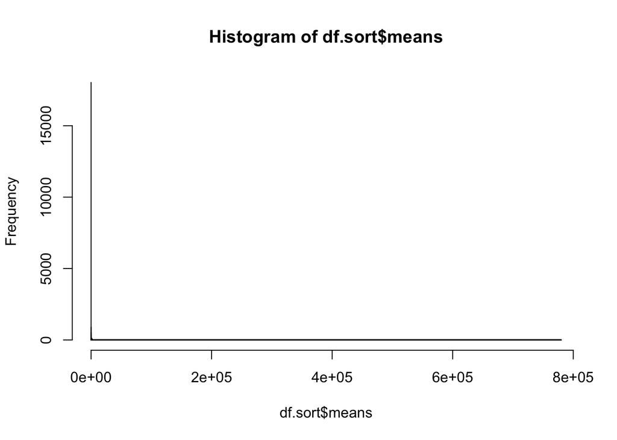

You can see that there is a peak close to 0 and a long tail extending to all the way 800000.

**What does this tell us about gene expression in the brain?**

**Click here**

It shows that most genes are not abundantly expressed and have low expression values.

It is hard to tell what are the low expression values making up the peak. Thus we can set the x-axis limits using `xlim=` argument instructing R to plot the histogram only for the genes with average read count between 0 and 1000.

```r
hist(df.sort$means, breaks = 50000, xlim = c(0,1000))
```

**Click here to see the plot**

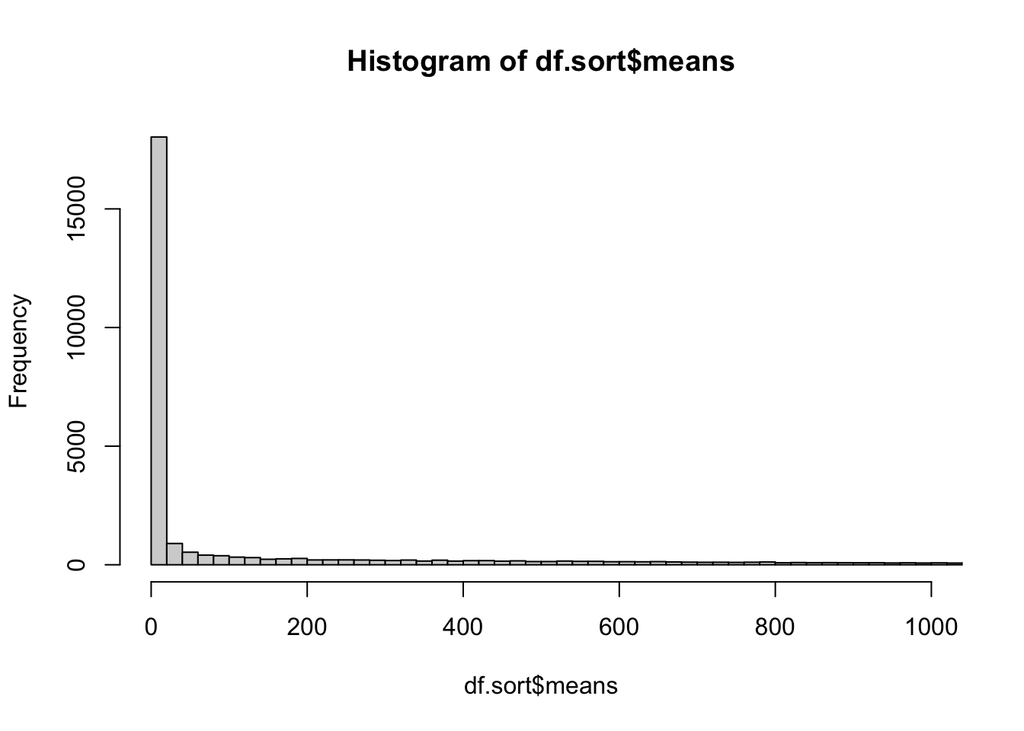

As we cannot trust the low expression values it is a good reason for excluding them from further analysis. To do this we can use the `dplyr::filter()` command and filter genes that have average gene count less than 100.

**TASK. Filter `df.sort` for values in ‘means’ column to be greater or equal to 100. Save the results as a new data frame named `df.sort.filt`**

**Click here to see the code**

```r
df.sort.filt <- dplyr::filter(df.sort, means >= 100)
```

Now plot a new histogram using `df.sort.filt` as input to see if it worked.

**Click here to see the plot**

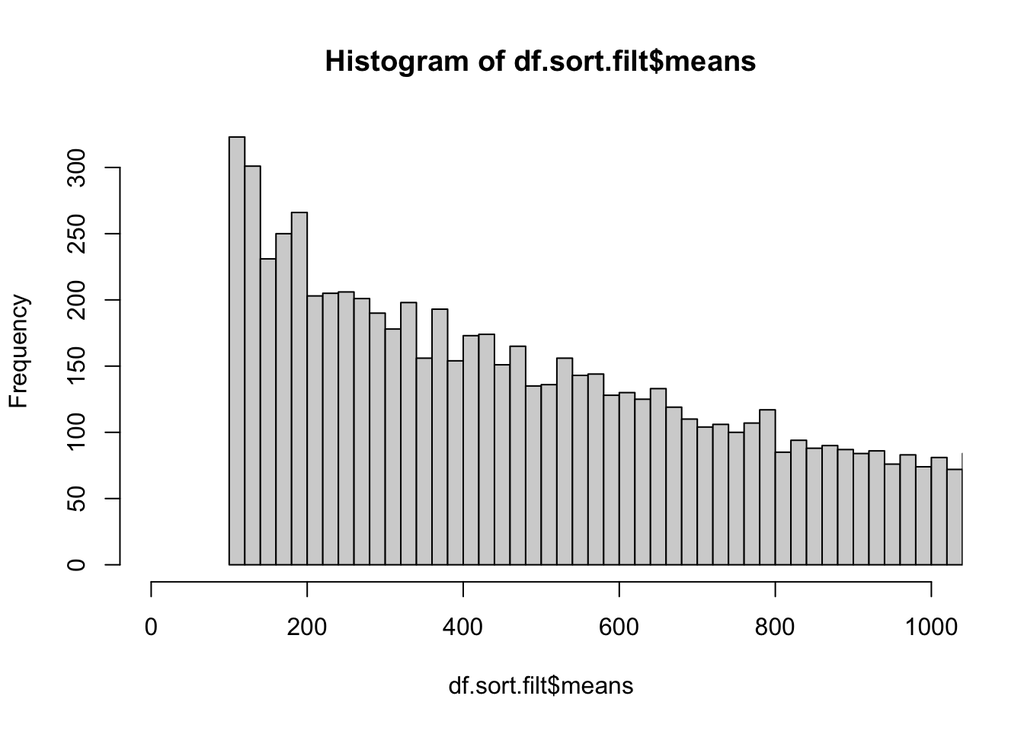

You can see this succesfully removed genes with `means <= 100`

**Click here if you can’t figure out the code**

```r
hist(df.sort.filt$means, breaks = 50000, xlim = c(0,1000))
```

Alternatively, we can visualise the read count of every gene in the genome for each individual sample using `boxplot()` command. As we wish to do that for each individual sample we will use `[ ]` and `:` operators to indicate which columns we wish to plot. Leaving the 1st argument in `[ ]` empty instructs R to plot a histogram for all rows (genes) in each indicated column.

```r
boxplot(df.sort.filt[,2:11])
```

**Click here to see the plot**

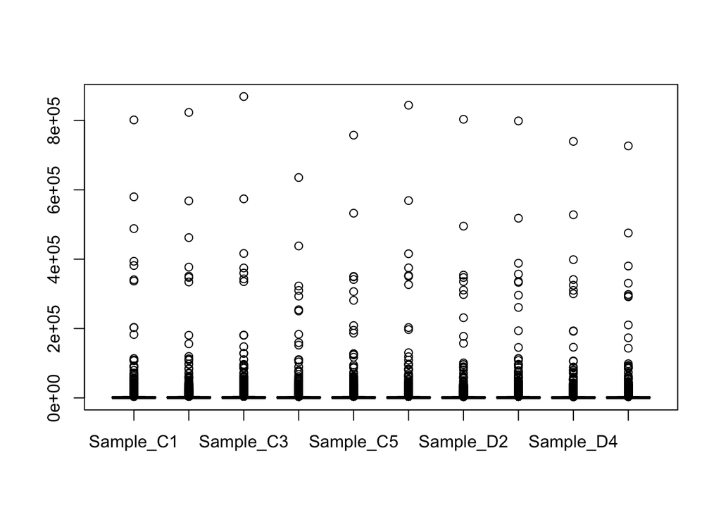

We see a similar pattern to that in the frequency histogram. There are few highly expressed genes whilst most genes have low expression values. Using `boxplot()` we can also see that the expression pattern is similar across all samples.

Similar to the histogram, low expression values are squished at the bottom. Thus we can change the `ylim=` argument to set the expression values between 0 and 5000. * We can also label the graph using `main=""` argument * Similarly, we can label x and y axis using `xlab=""` and `ylab=""` arguments

**TASK. Draw another boxplot titled “Read count boxplot” which would display read counts from 0 to 5000. Label x axis as “Samples” and y axis as ‘Read Counts’.**

**Click here to see the plot**

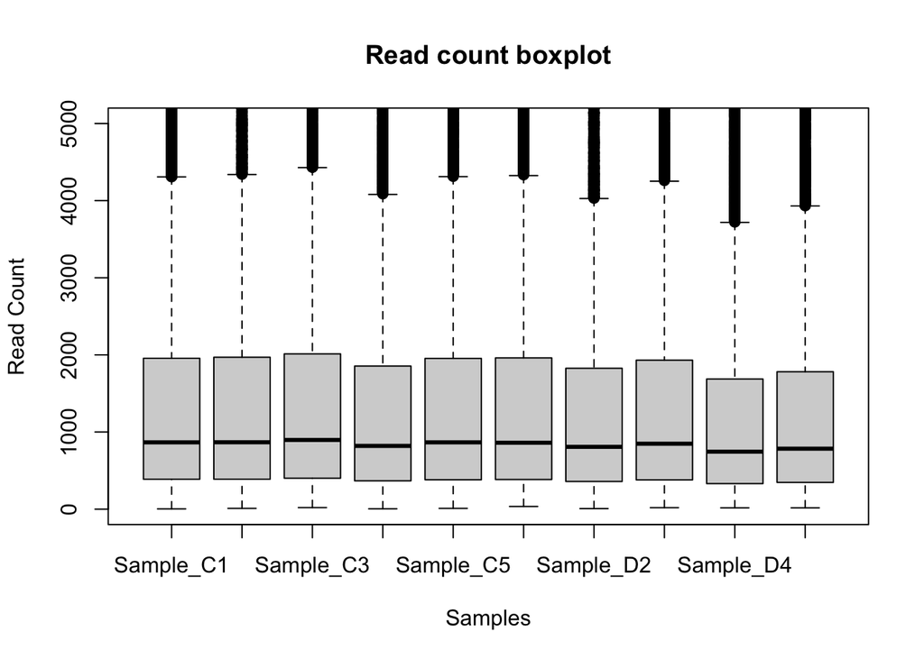

**Click here to see the code**

```r
boxplot(df.sort.filt[,2:11],
        ylim = c(0, 5e+03),
        main = "Read count box plot",
        xlab = "Samples",
        ylab = "Read Count")
```

### 3.8. Exploring gene expression using R

We know that columns Sample_C1 to C5 correspond to control samples while columns D1 to D5 to dehydrated samples. We may be interested in genes that change expression in response to dehydration.

We can investigate this without any statistical testing. One way would to do it would be to subtract the average read counts in dehydrated samples from the average read counts in control samples for each gene. We have computed these earlier and wrote them into `mean.con` and `mean.deh` columns in `df.sort.filt` data frame.

To do this we can use a simple arithmetic expression using the `-` operator.

It is also useful to save the results as a new column labelled `diff`.

```r
df.sort.filt$diff <- df.sort.filt$mean.con - df.sort.filt$mean.deh
# generate a simple xy plot visualising between avg reads and difference between groups
```

**Click here to see result**

```
##       Ensembl_geneID Sample_C1 Sample_C2 Sample_C3 Sample_C4 Sample_C5
## 1 ENSRNOG00000034234    801574    823254    869097    635491    757701
## 2 ENSRNOG00000031979    579853    567980    574038    438134    532600
## 3 ENSRNOG00000031033    488238    462219    416499    322726    350350
## 4 ENSRNOG00000030700    381673    377171    374708    293368    341400
## 5 ENSRNOG00000030371    336850    351084    359882    309987    348925
## 6 ENSRNOG00000030644    393943    334223    343259    254123    306509
##   Sample_D1 Sample_D2 Sample_D3 Sample_D4 Sample_D5 symbol
## 1    843991    803420    798712    739662    726652   COX1
## 2    569009    495278    518082    528137    475542   ATP6
## 3    415692    354065    388316    398697    380313    ND2
## 4    374996    347109    357059    324918    330772   COX3
## 5    353151    310838    333069    310064    298213   COX2
## 6    350529    335420    335910    341291    293971    ND1
##                      description    means mean.con mean.deh    diff
## 1 cytochrome c oxidase subunit 1 779955.4 777423.4 782487.4 -5064.0
## 2               ATPase subunit 6 527865.3 538521.0 517209.6 21311.4
## 3   NADH dehydrogenase subunit 2 397711.5 408006.4 387416.6 20589.8
## 4 cytochrome c oxidase subunit 3 350317.4 353664.0 346970.8  6693.2
## 5                          COXII 331206.3 341345.6 321067.0 20278.6
## 6   NADH dehydrogenase subunit 1 328917.8 326411.4 331424.2 -5012.8
```

**TASK. Generate a new frequency histogram having 10000 breaks for `diff` column of `df.sort.filt`**

**Click here to see the plot**

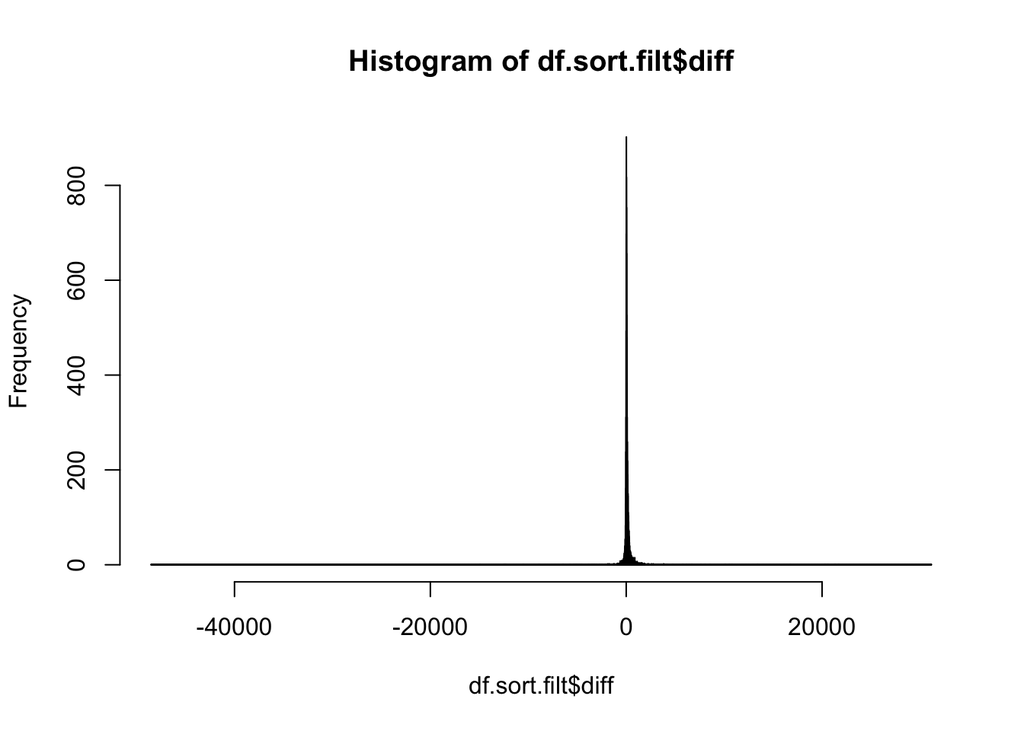

**Click here if you can’t figure out the code**

```r
hist(df.sort.filt$diff, breaks = 10000)
```

As you can see from the histogram, most genes have very small difference values between control and dehydrated samples, i.e. they are **not** differentially expressed.

We can further explore the relationship between average read count and difference between groups in a simple xy scatter plot using `plot()` command.

```r
plot(x=df.sort.filt$means,
     y=df.sort.filt$diff)
```

**Click here to see the plot**

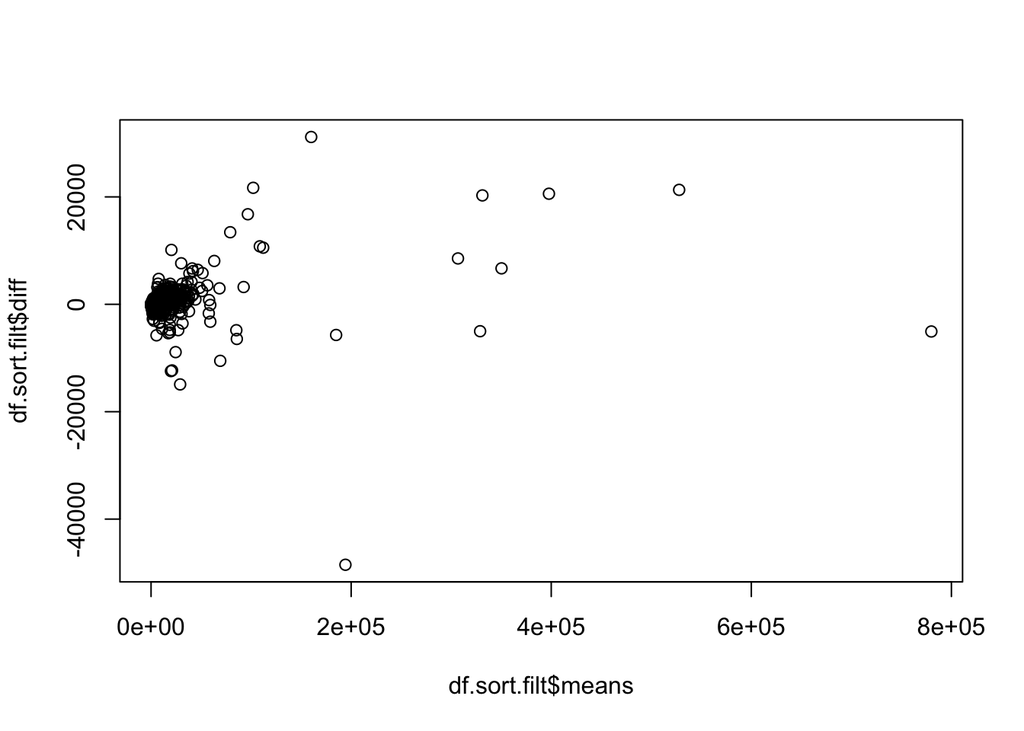

We can also supplement the plot with vertical and horizontal lines using `abline()` command right after the plot. Here, I used `mean(df.sort.filt$means)` command to derive the average mean read count for all genes to be plotted as a vertical line. Horizontal line is plotted for 0 and represent no difference between the control and dehydrated samples.

```r
plot(x=df.sort.filt$means,
     y=df.sort.filt$diff)+
abline(v=2185.753, h=0, col="blue")
```

**Click here to see the plot**

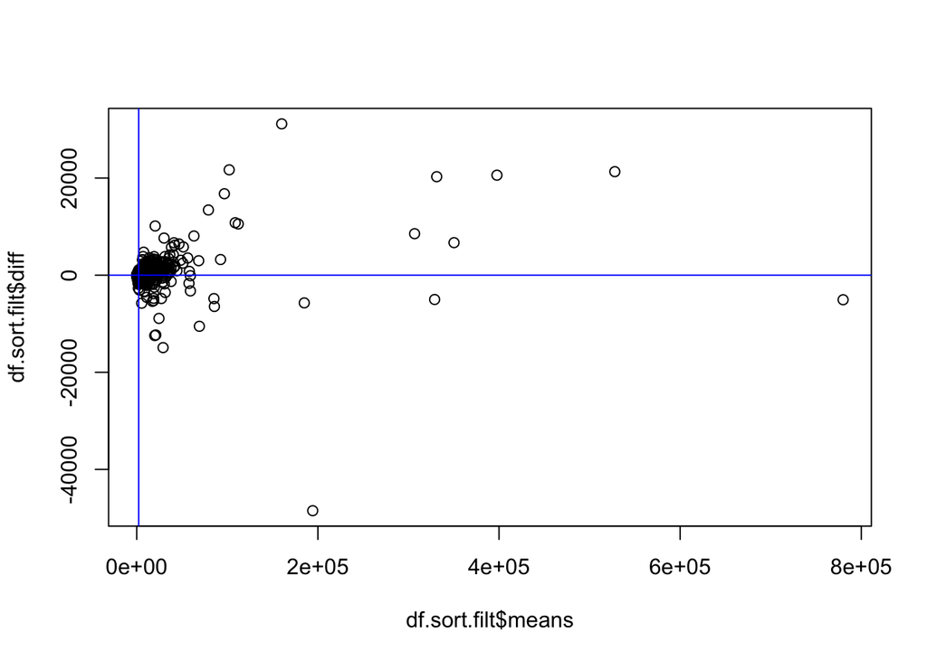

From this plot we can tell few things:

- Most genes are not abundantly expressed and tend to cluster on the left side of the plot.
- Most genes don’t have large difference between mean control and dehydrated read count values.
- Ones that do have larger difference values tend to be more abundantly expressed.

This reveals an important aspect of biology. **Relevance of biological effects is typically on a relational scale.**

For this we need to normalise `diff` by average gene expression in `means` column.  
Just like the last time we can use a simple arithmetic operator `\` and will save the results in a new column labeled `diff.norm`.

```r
df.sort.filt$diff.norm <- df.sort.filt$diff/df.sort.filt$means
```

**TASK. Using example from before, generate a new frequency histogram having 100 breaks for `diff.norm` column of `df.sort.filt`**

**Click here to see the plot**

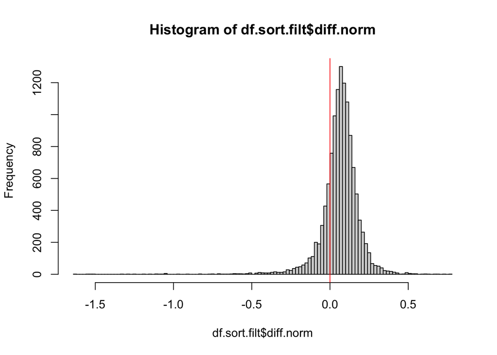

**Click here if you can’t figure out the code**

```r
hist(df.sort.filt$diff.norm, breaks = 100)
```

**TASK. Using example from before, generate a xy scatter plot showing the relationship between `diff.norm` and `means` columns**

**Click here to see the plot**

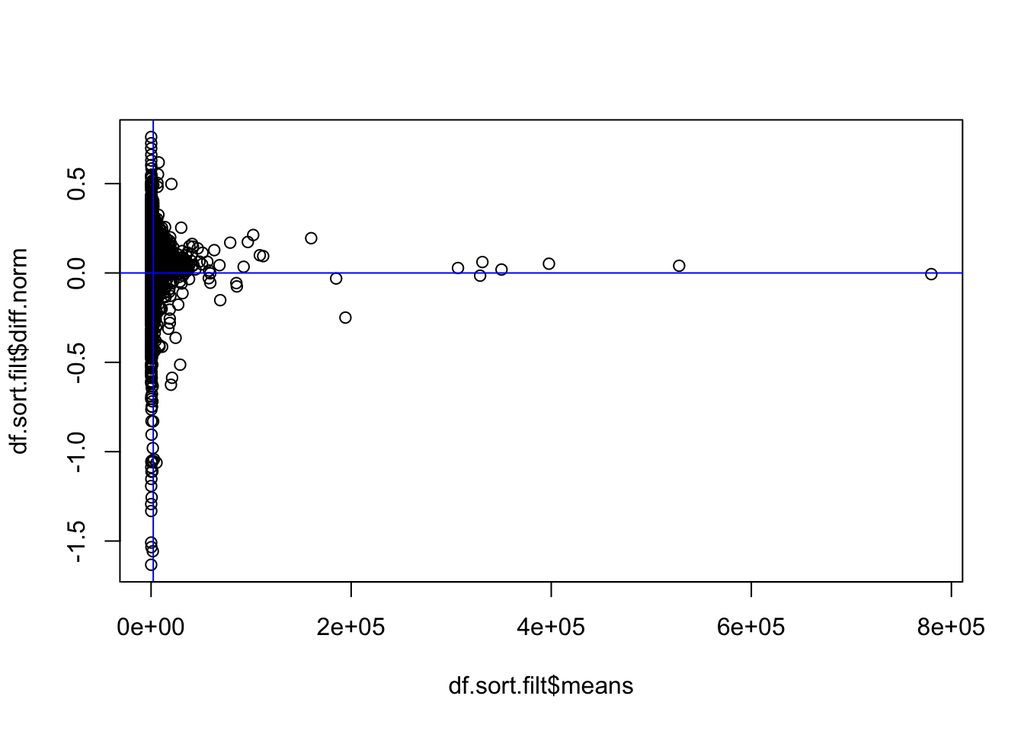

**Click here if you can’t figure out the code**

```r
plot(x=df.sort.filt$means,
     y=df.sort.filt$diff.norm)
abline(v=2185.753, h=0, col="blue")
```

This reveals another important aspect about gene expression. **It is much easier to double something that is lowly expressed rather than doubling something that is abundant**.

As we have generated columns containing values with **absolute** and **relative** difference in read counts for each gene we can easily lookup top 10 genes with greatest expression change for each.

```r
head(dplyr::arrange(test.df.sort.filtByDiffNorm, desc(diff)), 10) # Listing top5 genes with largest read difference
head(dplyr::arrange(test.df.sort.filtByDiffNorm, desc(diff.norm)), 10) # Listing top5 genes with largest read difference
```